# Ford GoBike System Data Exploration

# Introduction

This data set includes information about individual rides made in a bike-sharing system covering the greater San Francisco Bay area.

Note that this dataset will require some data wrangling in order to make it tidy for analysis. There are multiple cities covered by the linked system, and multiple data files will need to be joined together if a full year’s coverage is desired. If you’re feeling adventurous, try adding in analysis from other cities.

#### The Data

- duration_sec (seconds)
- start_time
- end_time
- Start Station ID
- start_station_name
- Start Station Latitude
- Start Station Longitude
- End Station ID
- End Station Name
- End Station Latitude
- End Station Longitude
- Bike ID
- User Type (Subscriber or Customer – “Subscriber” = Member or “Customer” = Casual)
- member_birth_year
- member_gender

```python
# import all packages
import numpy as np
import pandas as pd
import matplotlib.pyplot as plt
import seaborn as sb

%matplotlib inline
```

```python
# load in the dataset into a pandas dataframe
fordgobike_df = pd.read_csv('tripdata.csv')
```

```python
# high-level overview of data shape and composition
print(fordgobike_df.shape)
print(fordgobike_df.dtypes)
```

```
(519700, 15)
duration_sec                 int64
start_time                  object
end_time                    object
start_station_id             int64
start_station_name          object
start_station_latitude     float64
start_station_longitude    float64
end_station_id               int64
end_station_name            object
end_station_latitude       float64
end_station_longitude      float64
bike_id                      int64
user_type                   object
member_birth_year          float64
member_gender               object
dtype: object
```

# Gathering Data

```python
fordgobike_df.head()
```

|  | duration_sec | start_time | end_time | start_station_id | start_station_name | start_station_latitude | start_station_longitude | end_station_id | end_station_name | end_station_latitude | end_station_longitude | bike_id | user_type | member_birth_year | member_gender |
| --- | --- | --- | --- | --- | --- | --- | --- | --- | --- | --- | --- | --- | --- | --- | --- |
| 0 | 80110 | 2017-12-31 16:57:39.6540 | 2018-01-01 15:12:50.2450 | 74 | Laguna St at Hayes St | 37.776435 | -122.426244 | 43 | San Francisco Public Library (Grove St at Hyde... | 37.778768 | -122.415929 | 96 | Customer | 1987.0 | Male |
| 1 | 78800 | 2017-12-31 15:56:34.8420 | 2018-01-01 13:49:55.6170 | 284 | Yerba Buena Center for the Arts (Howard St at ... | 37.784872 | -122.400876 | 96 | Dolores St at 15th St | 37.766210 | -122.426614 | 88 | Customer | 1965.0 | Female |
| 2 | 45768 | 2017-12-31 22:45:48.4110 | 2018-01-01 11:28:36.8830 | 245 | Downtown Berkeley BART | 37.870348 | -122.267764 | 245 | Downtown Berkeley BART | 37.870348 | -122.267764 | 1094 | Customer | NaN | NaN |
| 3 | 62172 | 2017-12-31 17:31:10.6360 | 2018-01-01 10:47:23.5310 | 60 | 8th St at Ringold St | 37.774520 | -122.409449 | 5 | Powell St BART Station (Market St at 5th St) | 37.783899 | -122.408445 | 2831 | Customer | NaN | NaN |
| 4 | 43603 | 2017-12-31 14:23:14.0010 | 2018-01-01 02:29:57.5710 | 239 | Bancroft Way at Telegraph Ave | 37.868813 | -122.258764 | 247 | Fulton St at Bancroft Way | 37.867789 | -122.265896 | 3167 | Subscriber | 1997.0 | Female |

```python
fordgobike_df.isnull().sum()
```

```
duration_sec                   0
start_time                     0
end_time                       0
start_station_id               0
start_station_name             0
start_station_latitude         0
start_station_longitude        0
end_station_id                 0
end_station_name               0
end_station_latitude           0
end_station_longitude          0
bike_id                        0
user_type                      0
member_birth_year          66541
member_gender              66462
dtype: int64
```

```python
fordgobike_df.dropna(inplace=True)
```

```python
fordgobike_df.isnull().sum()
```

```
duration_sec               0
start_time                 0
end_time                   0
start_station_id           0
start_station_name         0
start_station_latitude     0
start_station_longitude    0
end_station_id             0
end_station_name           0
end_station_latitude       0
end_station_longitude      0
bike_id                    0
user_type                  0
member_birth_year          0
member_gender              0
dtype: int64
```

```python
fordgobike_df.duplicated().sum()
```

```
0
```

```python
fordgobike_df.describe()
```

|  | duration_sec | start_station_id | start_station_latitude | start_station_longitude | end_station_id | end_station_latitude | end_station_longitude | bike_id | member_birth_year |
| --- | --- | --- | --- | --- | --- | --- | --- | --- | --- |
| count | 453159.000000 | 453159.000000 | 453159.000000 | 453159.000000 | 453159.000000 | 453159.000000 | 453159.000000 | 453159.000000 | 453159.000000 |
| mean | 832.934014 | 95.046132 | 37.771968 | -122.364093 | 91.854907 | 37.772090 | -122.363274 | 1680.628285 | 1980.404787 |
| std | 2525.280717 | 84.578497 | 0.084914 | 0.104240 | 83.053529 | 0.084811 | 0.103723 | 972.828314 | 10.513488 |
| min | 61.000000 | 3.000000 | 37.317298 | -122.444293 | 3.000000 | 37.317298 | -122.444293 | 10.000000 | 1886.000000 |
| 25% | 364.000000 | 25.000000 | 37.773492 | -122.411726 | 24.000000 | 37.773793 | -122.409851 | 795.000000 | 1974.000000 |
| 50% | 556.000000 | 67.000000 | 37.782411 | -122.398525 | 66.000000 | 37.782411 | -122.397405 | 1739.000000 | 1983.000000 |
| 75% | 838.000000 | 138.000000 | 37.795392 | -122.391034 | 134.000000 | 37.795392 | -122.391034 | 2530.000000 | 1988.000000 |
| max | 86252.000000 | 340.000000 | 37.880222 | -121.874119 | 340.000000 | 37.880222 | -121.874119 | 3733.000000 | 1999.000000 |

```python
fordgobike_df.info()
```

```
<class 'pandas.core.frame.DataFrame'>
Int64Index: 453159 entries, 0 to 519699
Data columns (total 15 columns):
duration_sec               453159 non-null int64
start_time                 453159 non-null object
end_time                   453159 non-null object
start_station_id           453159 non-null int64
start_station_name         453159 non-null object
start_station_latitude     453159 non-null float64
start_station_longitude    453159 non-null float64
end_station_id             453159 non-null int64
end_station_name           453159 non-null object
end_station_latitude       453159 non-null float64
end_station_longitude      453159 non-null float64
bike_id                    453159 non-null int64
user_type                  453159 non-null object
member_birth_year          453159 non-null float64
member_gender              453159 non-null object
dtypes: float64(5), int64(4), object(6)
memory usage: 55.3+ MB
```

```python
# set dates to timestamps
fordgobike_df.start_time = pd.to_datetime(fordgobike_df.start_time)
fordgobike_df.end_time = pd.to_datetime(fordgobike_df.end_time)
```

```python
# set user type, gender and bike_share_for_all_trip to category
fordgobike_df.user_type = fordgobike_df.user_type.astype('category')
fordgobike_df.member_gender = fordgobike_df.member_gender.astype('category')
```

```python
# set bike id, start_station_id, end_station_id to object
fordgobike_df.bike_id = fordgobike_df.bike_id.astype(str)
fordgobike_df.start_station_id = fordgobike_df.bike_id.astype(str)
fordgobike_df.end_station_id = fordgobike_df.bike_id.astype(str)
```

```python
fordgobike_df.info()
```

```
<class 'pandas.core.frame.DataFrame'>
Int64Index: 453159 entries, 0 to 519699
Data columns (total 15 columns):
duration_sec               453159 non-null int64
start_time                 453159 non-null datetime64[ns]
end_time                   453159 non-null datetime64[ns]
start_station_id           453159 non-null object
start_station_name         453159 non-null object
start_station_latitude     453159 non-null float64
start_station_longitude    453159 non-null float64
end_station_id             453159 non-null object
end_station_name           453159 non-null object
end_station_latitude       453159 non-null float64
end_station_longitude      453159 non-null float64
bike_id                    453159 non-null object
user_type                  453159 non-null category
member_birth_year          453159 non-null float64
member_gender              453159 non-null category
dtypes: category(2), datetime64[ns](2), float64(5), int64(1), object(5)
memory usage: 49.3+ MB
```

```python
# substract the birth year from the current year
fordgobike_df['age'] = 2020-fordgobike_df['member_birth_year']
```

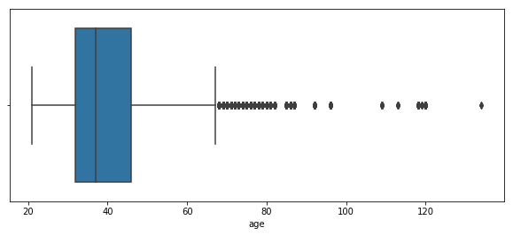

```python
# code for the age boxplot

plt.figure(figsize = [10, 4])
base_color = sb.color_palette()[0]

sb.boxplot(data=fordgobike_df, x='age', color=base_color);
```

```python
# extract start time month name
fordgobike_df['month_name']=fordgobike_df['start_time'].dt.strftime('%B')
# extract start time month number
fordgobike_df['N_month']=fordgobike_df['start_time'].dt.month.astype(int)
# extract start time weekdays
fordgobike_df['weekday']=fordgobike_df['start_time'].dt.strftime('%a')

# extract start time day
fordgobike_df['day']=fordgobike_df['start_time'].dt.day.astype(int)
# extract start time hour
fordgobike_df['hour']=fordgobike_df['start_time'].dt.hour
```

```python
fordgobike_df.head(3)
```

[output not shown]

```python
fordgobike_df.info(verbose=True, null_counts=True)
```

[output not shown]

```python
fordgobike_df.age.mean()
```

```
38.386687406383224
```

```python
fordgobike_df.age.describe(percentiles = [ .95])
```

[output not shown]

```python
# Keep records below 60, removes null values and outliers
fordgobike_df = fordgobike_df.query('age <=60')
```

```python
# change age and birth year to integer
fordgobike_df.member_age = fordgobike_df.age.astype(int)
fordgobike_df.member_birth_year = fordgobike_df.member_birth_year.astype(int)
```

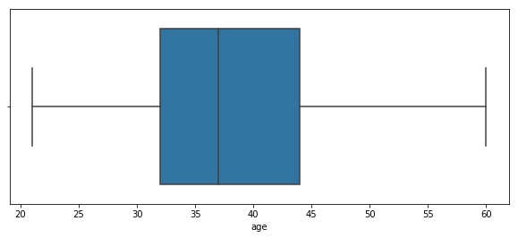

```python
# code for the age boxplot

plt.figure(figsize = [10, 4])
base_color = sb.color_palette()[0]

sb.boxplot(data=fordgobike_df, x='age', color=base_color);
```

```python
# substract the birth year from the current year
fordgobike_df['duration_minute']= fordgobike_df['duration_sec']/60
```

```python
fordgobike_df.head(3)
```

[output not shown]

```python
fordgobike_df.dtypes
```

```
duration_sec                        int64
start_time                 datetime64[ns]
end_time                   datetime64[ns]
start_station_id                   object
start_station_name                 object
start_station_latitude            float64
start_station_longitude           float64
end_station_id                     object
end_station_name                   object
end_station_latitude              float64
end_station_longitude             float64
bike_id                            object
user_type                        category
member_birth_year                   int32
member_gender                    category
age                               float64
month_name                         object
N_month                             int32
weekday                            object
day                                 int32
hour                                int64
duration_minute                   float64
dtype: object
```

### What is the structure of your dataset?

Originally there were approx. 519700 bike rides features about:

### What is/are the main feature(s) of interest in your dataset?

I'm most interested age to know what the group ages most commonly make trips and long trips

### What features in the dataset do you think will help support your investigation into your feature(s) of interest?

i expect the duration time and gender type very important for me to help me for the relationship between long of the trip and effectness of that for the gender and the age groups

# Univariate Exploration

I'll start by looking at the duration of the trip and the monthly number of bike distribution of weekdays and hours of the day. I will also explore the ages and gender to know how strongly relationship between this three feature and how it can effectiveness on the decision maker

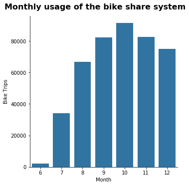

```python
# start with a standard-scaled plot
# monthly usege of the bike sharing system
g = sb.catplot(data=fordgobike_df, x='N_month', kind='count', color = base_color)
g.set_axis_labels("Month", "Bike Trips")
g.fig.suptitle('Monthly usage of the bike share system', y=1.03, fontsize=16, fontweight='bold');
```

as we see month of october is highest number appear

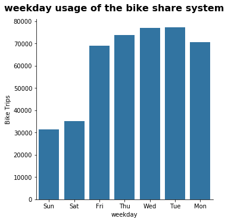

```python
# start with a standard-scaled plot
# monthly usege of the bike sharing system
g = sb.catplot(data=fordgobike_df, x='weekday', kind='count', color = base_color)
g.set_axis_labels("weekday", "Bike Trips")
g.fig.suptitle('weekday usage of the bike share system', y=1.03, fontsize=16, fontweight='bold');
```

as we see from monday to friday is the highest number because all this days of work but sat and sun the days off for employee

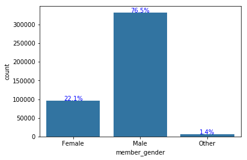

```python
# create the plot
base_color = sb.color_palette()[0]
sb.countplot(data = fordgobike_df, x = 'member_gender', color = base_color)

# add annotations
n_points = fordgobike_df.shape[0]
cat_counts = fordgobike_df['member_gender'].value_counts()
locs, labels = plt.xticks() # get the current tick locations and labels

# loop through each pair of locations and labels
for loc, label in zip(locs, labels):

    # get the text property for the label to get the correct count
    count = cat_counts[label.get_text()]
    pct_string = '{:0.1f}%'.format(100*count/n_points)

    # print the annotation just below the top of the bar
    plt.text(loc, count-8, pct_string, ha = 'center', color = 'b')
```

reegarding for that visualization the male is the highest number of appearance

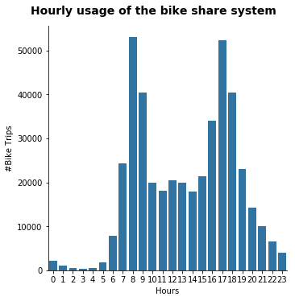

```python
g = sb.catplot(data=fordgobike_df, x='hour', kind='count', color = base_color)
g.set_axis_labels("Hours", "#Bike Trips")
g.fig.suptitle('Hourly usage of the bike share system', y=1.03, fontsize=14, fontweight='semibold');
```

The hourly distribution is bimodal, the system is used mainly around 8-9am and 5-6pm when people get to and gat back from work.

- hourly usege of the bike sharing system to know what the specific time we need to know to puch more offer on it to make a good motovition

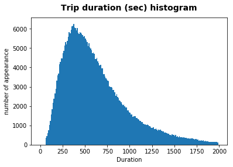

```python
bin_edges = np.arange(0,2000,10)

plt.hist(data = fordgobike_df, x = 'duration_sec', bins = bin_edges)

plt.title("Trip duration (sec) histogram", y=1.03, fontsize=14, fontweight='semibold')
plt.xlabel('Duration')
plt.ylabel('number of appearance');
```

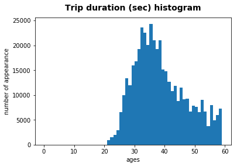

```python
bin_edges = np.arange(0, 60,1)

plt.hist(data = fordgobike_df, x = 'age', bins = bin_edges)

plt.title("Trip duration (sec) histogram", y=1.03, fontsize=14, fontweight='semibold')
plt.xlabel('ages')
plt.ylabel('number of appearance');
```

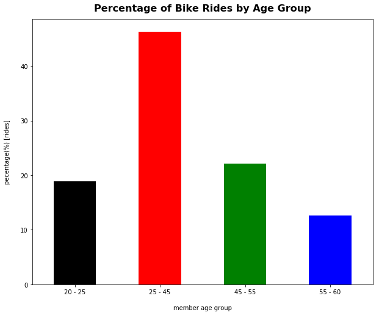

```python
#Generate a new column member_age_bins from member age group
fordgobike_df['member_age_bins'] = fordgobike_df['age'].apply(lambda x: '10 - 20' if 10<x<=20
                                                  else '20 - 25' if 20<x<=30
                                                  else '25 - 45' if 30<x<=40
                                                  else '45 - 55' if 40<x<=50
                                                  else '55 - 60' if 50<x<=60
                                                  else x)

trip_agegroup_df = fordgobike_df.groupby('member_age_bins').agg({'bike_id':'count'})

trip_agegroup_df['percentage'] = (trip_agegroup_df['bike_id']/trip_agegroup_df['bike_id'].sum())*100

new_color = ['black', 'red', 'green', 'blue', 'cyan']
trip_agegroup_df['percentage'].plot(kind='bar', color=new_color, figsize=(10,8))
plt.title('Percentage of Bike Rides by Age Group', fontsize=16, y=1.015,fontweight='semibold')
plt.xlabel('member age group', labelpad=16)
plt.ylabel('pecentage(%) [rides]', labelpad=16)
plt.xticks(rotation=360)
```

other way not normal most of youn youth under 20 year not appear on the distribution that mean they not prefer to ride the bike or the that expensive to payed lot of money or there home nearest and not need to ride the bike

### Of the features you investigated, were there any unusual distributions? Did you perform any operations on the data to tidy, adjust, or change the form of the data? If so, why did you do this?

There was one unusal distribution for the ages some of ages more than 100 and 120 years but that rare so i exclude that and saves the duration between 20 to 60

# Bivariate Exploration

```python
customer = fordgobike_df.query('user_type == "Customer"')['bike_id'].count()
subscriber = fordgobike_df.query('user_type == "Subscriber"')['bike_id'].count()

customer_proportion = customer / fordgobike_df['bike_id'].count()
subscriber_proportion = subscriber / fordgobike_df['bike_id'].count()
```

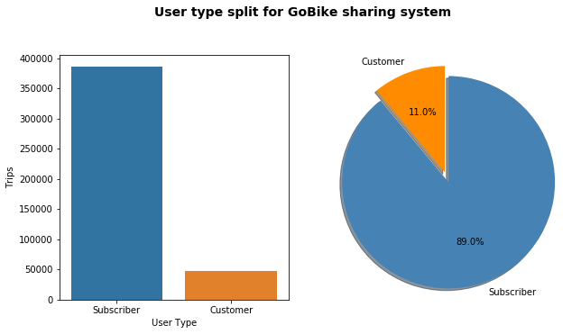

```python
plt.figure(figsize = [10, 5])

# code for the bar chart
plt.subplot(1, 2, 1)

g = sb.countplot(data=fordgobike_df, x="user_type", order=fordgobike_df.user_type.value_counts().index)
g.set_xlabel('User Type')
g.set_ylabel('Trips')

# code for the pie chart
plt.subplot(1, 2, 2)

labels = ['Customer', 'Subscriber']
sizes = [customer_proportion, subscriber_proportion]
colors = ['darkorange', 'steelblue']
explode = (0, 0.1)

plt.pie(sizes, explode=explode, labels=labels, colors = colors,
        autopct='%1.1f%%', shadow=True, startangle=90)
plt.axis('equal')

plt.suptitle('User type split for GoBike sharing system', y=1.03, fontsize=14, fontweight='semibold');
```

```python
usertype_count_df = fordgobike_df.groupby(["N_month", "user_type"]).size().reset_index()
```

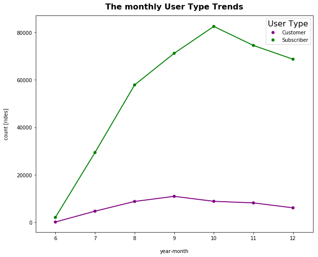

```python
import matplotlib.ticker as tick
plt.figure(figsize=(10,8))
colors = {'Subscriber':'Green', 'Customer':'purple'}
ax = sb.pointplot(x='N_month', y=0, hue='user_type', palette=colors, scale=.7, data=usertype_count_df)
plt.title('The monthly User Type Trends', fontsize=16, y=1.015,fontweight='semibold')
plt.xlabel('year-month', labelpad=16)
plt.ylabel('count [rides]', labelpad=16)
leg = ax.legend()
leg.set_title('User Type',prop={'size':16})
ax = plt.gca()
#ax.yaxis.set_major_formatter(tick.FuncFormatter(transform_axis_fmt))
```

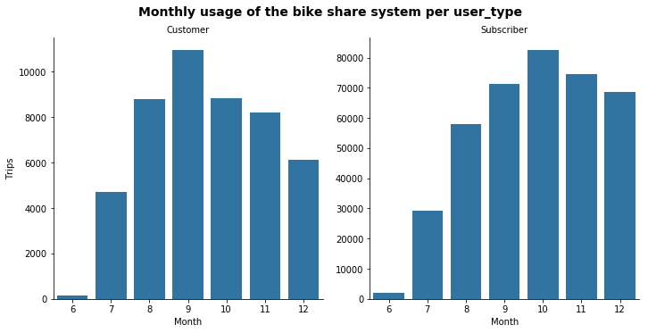

```python
# monthly usege of the bike sharing system per user type
g = sb.catplot(data=fordgobike_df, x='N_month', col="user_type", kind='count', sharey = False,
            color = base_color)
g.set_axis_labels("Month", "Trips")
g.set_titles("{col_name}")
g.fig.suptitle('Monthly usage of the bike share system per user_type', y=1.03, fontsize=14, fontweight='semibold');
```

both of customer and subscribe from 7 to 10 have more time to ride the bike

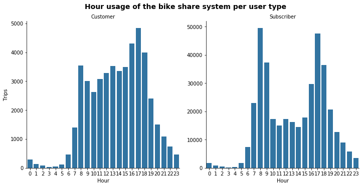

```python
# hourly usege of the bike sharing system per user type

g = sb.catplot(data=fordgobike_df, x='hour', col="user_type", kind='count', sharey = False,
            color = base_color)
g.set_axis_labels("Hour", "Trips")
g.set_titles("{col_name}")
g.fig.suptitle('Hour usage of the bike share system per user type', y=1.03, fontsize=14, fontweight='semibold');
```

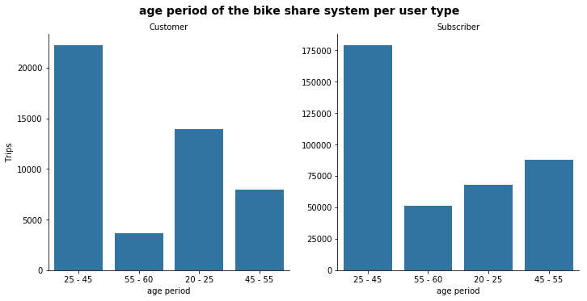

```python
# age period   of the bike sharing system per user type

g = sb.catplot(data=fordgobike_df, x='member_age_bins', col="user_type", kind='count', sharey = False,
            color = base_color)
g.set_axis_labels("age period", "Trips")
g.set_titles("{col_name}")
g.fig.suptitle('age period of the bike share system per user type', y=1.03, fontsize=14, fontweight='semibold');
```

we see ages from 20 to 45 on the both of user type used the bike share

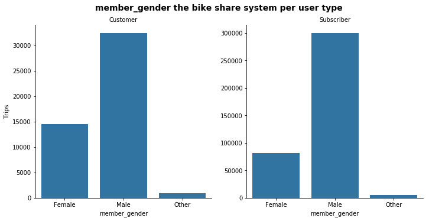

```python
# gender used   the bike sharing system per user type

g = sb.catplot(data=fordgobike_df, x='member_gender', col="user_type", kind='count', sharey = False,
            color = base_color)
g.set_axis_labels("member_gender", "Trips")
g.set_titles("{col_name}")
g.fig.suptitle('member_gender the bike share system per user type', y=1.03, fontsize=14, fontweight='semibold');
```

as we seen above the male more than gender type with customer and subscriber but the female rate on customer around the 50% but on subscribe i think the rate close to 30%

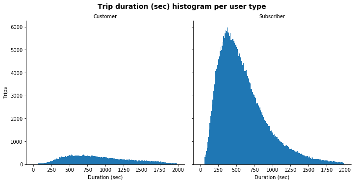

```python
# code for the (histogram) duration (sec) distribution per user type

g = sb.FacetGrid(fordgobike_df, col="user_type", margin_titles=True, size=5)
bin_edges = np.arange(0, 2000,10)
g.map(plt.hist, "duration_sec", color=base_color, bins=bin_edges)
g.set_axis_labels("Duration (sec)", "Trips")
g.set_titles(col_template = '{col_name}')
g.fig.suptitle('Trip duration (sec) histogram per user type', y=1.03, fontsize=14, fontweight='semibold');
```

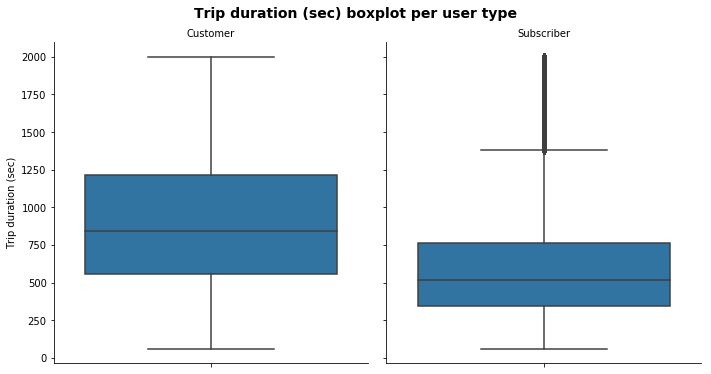

```python
# code for the (boxplot) duration (sec) distribution per user type

data = fordgobike_df.query('duration_sec < 2000')
g = sb.catplot(data=data, y='duration_sec', col="user_type", kind='box',
            color = base_color)
g.set_titles(col_template = '{col_name}')
g.set_axis_labels("", "Trip duration (sec)")
g.fig.suptitle('Trip duration (sec) boxplot per user type', y=1.03, fontsize=14, fontweight='semibold');
```

Looking at box plots we can see that trip durations are longer for customers than for subscribers . because we can see the mean and range of IQR on both two box plot

### Talk about some of the relationships you observed in this part of the investigation. How did the feature(s) of interest vary with other features in the dataset?

the relationships observed in this part of the investigation the user_type because in this feature i really know more information when i test this feature in univariate visualizaion and bivariate and multivariate visualization so in univariate i know the most frequesny appear is the subscribers more than customer and on biviaraite i compare and make corroletion co-effection between between this feature (categorical and some features like numerical featurs and categorical feature so i used barchar to make this investigation and retreive more information from this relations like in the (usertype and gender the male is the heiger rate used the bike)also time using i found most of them not more than 30 min and most frequent appear on the morining when they went to work and the time of return back from the work and also as per month i found the july to october most frequency appear on oth of user type

### Did you observe any interesting relationships between the other features (not the main feature(s) of interest)?

i extract the age from the birthday so i extarct the time duration in minute so this tue features very interseted to me because i anaylsis user_type on bivaraite regarding this new feature and i extract good information like maximum time appear and the time duration most frequentally appear

# Multivariate Exploration

**regarding for my thought the male more than more multible time so i will focus of the age group on this part**

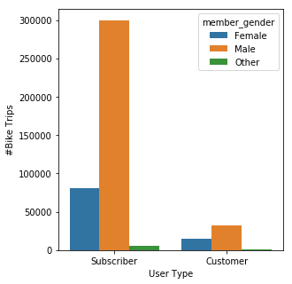

```python
plt.figure(figsize = [10, 5])

# code for the bar chart
plt.subplot(1, 2, 1)

gender= sb.countplot(data=fordgobike_df, x="user_type", hue="member_gender", order=fordgobike_df.user_type.value_counts().index)
gender.set_xlabel('User Type')
gender.set_ylabel('#Bike Trips');
```

As we see the males are using the system more than females and others However, the ratio is much smaller between males and females for customers around 50% and in subsribe around 30%

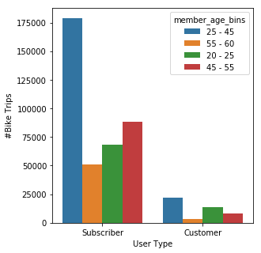

```python
plt.figure(figsize = [10, 5])
plt.subplot(1, 2, 1)
gender= sb.countplot(data=fordgobike_df, x="user_type", hue="member_age_bins",order=fordgobike_df.user_type.value_counts().index)
gender.set_xlabel('User Type')
gender.set_ylabel('#Bike Trips');
```

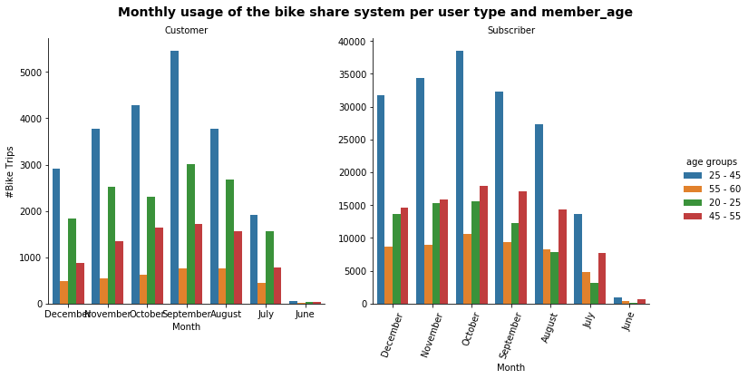

```python
# monthly usege of the bike sharing system per user type and ages group

g = sb.catplot(data=fordgobike_df, x='month_name', col="user_type", hue="member_age_bins", kind='count', sharey = False)
g.set_axis_labels("Month", "#Bike Trips")

g._legend.set_title('age groups')
g.set_titles("{col_name}")
g.fig.suptitle('Monthly usage of the bike share system per user type and member_age', y=1.03, fontsize=14, fontweight='semibold');
plt.xticks(rotation=70)
```

age groups very important trend to know how the company make a good offer or how the company go through to improve the quilty of the product so i interseted to splite the ages into categories and see what the effect happen with the monthely with user type so regarding for the visualization i see both things strangers :

- the ages between 25-45 more than on the both side of user types
- the ages between 45-55 higher on the subscribe rather than customer so i thing this age related by the mans on the moderate ages and they almost married and have a good job so they subscribers because they have stable life reverse on the customer user during all monthes almost the same number

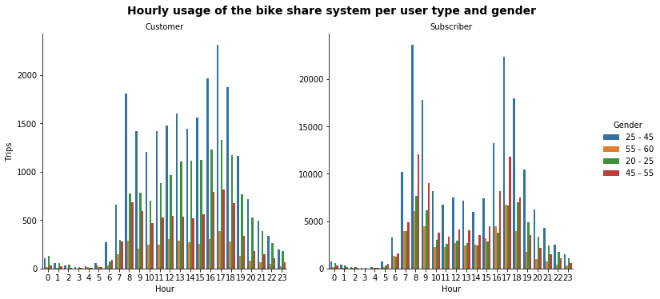

```python
# hourly usege of the bike sharing system per user type and gender

g = sb.catplot(data=fordgobike_df, x='hour', col="user_type", hue='member_age_bins', kind='count', sharey = False)
g.set_axis_labels("Hour", "Trips")
g._legend.set_title('Gender')
g.set_titles("{col_name}")
g.fig.suptitle('Hourly usage of the bike share system per user type and gender', y=1.03, fontsize=14, fontweight='semibold');
```

regarding of this visualization during the time between 7 to 9 on the both side all user type on the age between 20-45 went to their work and they return back on the time between 5 b to 7

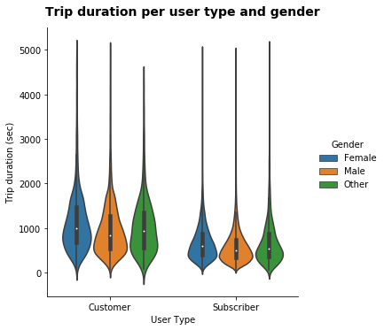

```python
# (violinplot) duration (sec) distribution per user type and gender
data = fordgobike_df.query('duration_sec <5000')

g = sb.catplot(data=data, x='user_type', y="duration_sec", hue="member_gender", kind="violin")

g.set_axis_labels("User Type", "Trip duration (sec)")
g._legend.set_title('Gender')
g.fig.suptitle('Trip duration per user type and gender', y=1.03, fontsize=14, fontweight='semibold');
```

we find females takes a longer trips (measured in time) than males and other on the both side on the user_types

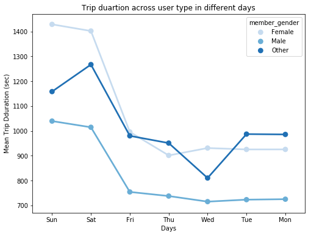

```python
fig = plt.figure(figsize = [8,6])
sb.pointplot(data = fordgobike_df, x = 'weekday', y = 'duration_sec', hue = 'member_gender', palette = 'Blues', ci=None)
plt.title('Trip duartion across user type in different days')
plt.ylabel('Mean Trip Dduration (sec)')
plt.xlabel('Days')
plt.show();
```

most of their take more time trip on the vactions days on sat and sun days and the pinter less almost of the reminder days on the week

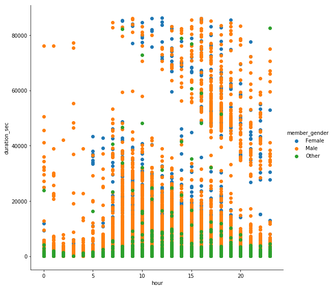

```python
plt.figure(figsize = [10, 5])
g = sb.FacetGrid(data = fordgobike_df, hue = 'member_gender', height = 8)
g.map(plt.scatter, 'hour', 'duration_sec');
g.add_legend();
```

as we see the female on the blue points is little but log durations